# MCCS DR Case-Cohort Simulation Results

Brian Richardson

07/12/2024

```r
rm(list = ls())
library(dplyr)
library(tidyverse)
library(ggplot2)
library(ggh4x)
library(kableExtra)
```

The goal of this program is to evaluate the Monte Carlo corrected score doubly robust (MCCS DR) estimator in the presence of confounding and measurement error.

## Setup

Consider the following setup:

- continuous confounder $L \sim U(0, 1)$,
- trivariate continuous exposure $\pmb{A} = (A_1, A_2, A_3)^T$ with $\pmb{A}|L$ having multivariate normal distribution $N_3\left(\begin{bmatrix} 0.4L \\ -0.4L \\ 0.2 - 0.1L \end{bmatrix}, \begin{bmatrix} 0.09 & 0 & 0 \\ 0 & 0.09 & 0 \\ 0 & 0 & 0.09 \end{bmatrix}\right)$.
- mismeasured exposure $\pmb{A}^* = (A^*_1, A^*_2, A^*_3)^T = \pmb{A} + \pmb{\epsilon}$, where $\pmb{\epsilon} = (\epsilon_1, \epsilon_2, \epsilon_3)^T \sim N(\pmb{0}, \pmb{\Sigma}_e)$, $\pmb{\Sigma}_e = \begin{bmatrix} \sigma_e^2 & 0 & 0 \\ 0 & \sigma_e^2 & 0 \\ 0 & 0 & 0\end{bmatrix}$.
- binary outcome $Y$ with $\textrm{E}(Y|\pmb{A},L) = \widetilde\gamma_0 + \widetilde\gamma_1 a_1 + \widetilde\gamma_2 a_2 + \widetilde\gamma_3 a_3 + \widetilde\gamma_4L + \widetilde\gamma_5 a_1L + \widetilde\gamma_6 a_2L + \widetilde\gamma_7 a_3L$, where $\widetilde{\pmb{\gamma}} = (\widetilde\gamma_0, \widetilde\gamma_1, \widetilde\gamma_2, \widetilde\gamma_3, \widetilde\gamma_4, \widetilde\gamma_5, \widetilde\gamma_6, \widetilde\gamma_7)^T = (0.4, 0.15, 0.15, 0.2, 0.1, 0.1, 0, -0.1)^T$.

This data generating process leads to the marginal structural model $\textrm{E}\{Y(\pmb{a})\} = \gamma_0 + \gamma_1 a_1 + \gamma_2 a_2 + \gamma_3 a_3$, where $\pmb{\gamma} = (\gamma_0, \gamma_1, \gamma_2, \gamma_3)^T = (0.45, 0.2, 0.15, 0.15)^T$.

The estimands of interest in these simulations are the values $\textrm{E}\{Y(\pmb{a})\}$ for various $a$ in the support of $A$.

## Methods

In these simulations, we compare three methods:

1. Naive DR,
2. Oracle DR,
3. Corrected DR.

Each estimator accounts for case-cohort sampling, where a proportion $\pi_{cc} \in [0,1]$ of cases are used in analysis. This sampling is accounted for by upweighting estimating equations using $1/ \widehat\pi_{cc}$.

## Results

```r
# load simulation results from each of 10 clusters
sim.out.list <- lapply(
  X = 0:9,
  FUN = function(clust) {
    cbind(clust,
          read.csv(paste0("sim_data/dr_cc_data/sd",
                          clust, ".csv")))
  })


# combine simulation results into 1 data frame
sim.out <- bind_rows(sim.out.list)

# true E{Y(a)} values
a <- matrix(
  c(-0.01709859, -0.41727369, -0.0531144,
    0.20031219, -0.19979007,  0.1498574,
    0.41804918,  0.01691357,  0.3536388),
  nrow = 3, ncol = 3, byrow = T)
EYa <- as.numeric(cbind(1, a) %*% c(0.45, 0.2, 0.15, 0.15))

# number of sims per setting
n.rep <- nrow(sim.out) / n_distinct(dplyr::select(sim.out, n, B, vare, pi.cc))

# make long data frame
sim.out.long <- sim.out %>%
  pivot_longer(cols = starts_with("ghat") |
                 starts_with("stde") |
                 starts_with("bste"),
               names_to = "method.param",
               values_to = "val") %>%
    mutate(method = factor(substr(method.param, 6, 6),
                           levels = c("O", "N", "C"),
                           labels = c("Oracle",
                                      "Naive",
                                      "Corrected")),
           param = factor(substr(method.param, 8, 8)),
           name = factor(substr(method.param, 1, 4)),
           g.true = EYa[param]) %>%
  dplyr::select(-method.param) %>%
  group_by(clust, n, B, vare, pi.cc, method, param, name) %>%
  mutate(id = row_number()) %>%
  pivot_wider(names_from = name,
              values_from = val,
              id_cols = c(clust, n, B, vare, pi.cc, method,
                          param, g.true, id)) %>%
  mutate(ci.lower = ghat - qnorm(0.975) * stde,
         ci.upper = ghat + qnorm(0.975) * stde,
         ci.cov = g.true >= ci.lower & g.true <= ci.upper,
         bcci.lower = ghat - qnorm(0.975) * bste,
         bcci.upper = ghat + qnorm(0.975) * bste,
         bcci.cov = g.true >= bcci.lower & g.true <= bcci.upper)
```

We first check for simulations with errors.

```r
# summarize proportion of errors in std errors by setting
ftc.dat <- sim.out.long %>%
  group_by(method, n, pi.cc, param) %>%
  summarise(prop.error = mean(is.na(ghat) | stde > 100))
ftc.dat %>%
  ungroup() %>%
  filter(prop.error > 0)
```

```
## # A tibble: 7 × 5
##   method        n pi.cc param prop.error
##   <fct>     <int> <dbl> <fct>      <dbl>
## 1 Corrected  2000  0.05 1          0.001
## 2 Corrected  2000  0.05 2          0.001
## 3 Corrected  2000  0.05 3          0.001
## 4 Corrected  2000  0.1  3          0.001
## 5 Corrected  2000  0.25 1          0.001
## 6 Corrected  2000  0.25 2          0.001
## 7 Corrected  2000  0.25 3          0.001
```

### Plots of simulation results

Below are boxplots of the empirical distributions of estimators for $\textrm{E}\{Y(\pmb{a})\}$.

```r
# extract simulation parameters
n <- unique(sim.out$n)
pi.cc <- unique(sim.out$pi.cc)

# make labels for plots
n.labs <- paste0("n = ", n)
names(n.labs) <- n

pi.cc.labs <- paste0("pi.cc = ", pi.cc)
names(pi.cc.labs) <- pi.cc

param.labs <- paste0("$\\eta(\\ba_", c("1", "2", "3", "4", "5"), ")$")
names(param.labs) <- 1:5

# colorblind friendly pallette
pal_light <- c('#EE6677', '#228833', '#4477AA', '#CCBB44', '#66CCEE', '#AA3377', '#BBBBBB')
pal_dark <- c('#991122', '#114419', '#223b55', '#6b611d', '#117799', '#55193b', '#5d5d5d')
```

```r
# create plots
make.plot <- function(title = T) {

  plot <- ggplot(
    data = sim.out.long,
    aes(x = method,
        y = ghat,
        fill = method,
        color = method)) +
    geom_boxplot() +
    stat_summary(fun = mean,
                 geom = "point",
                 shape = 8,
                 size = 2,
                 orientation = "x",
                 show.legend = F) +
    geom_hline(aes(yintercept = g.true),
               linetype = "dashed",
               color = "orange") +
    facet_nested(n + pi.cc ~ param,
                 scales = "free",
                 labeller = labeller(n = n.labs,
                                     param = param.labs)) +
    labs(y = "Parameter Estimate",
         fill = "Method",
         color = "Method") +
    theme_bw() +
    theme(axis.title.x = element_blank(),
          axis.ticks.x = element_blank(),
          axis.text.x = element_blank(),
          legend.position = "bottom") +
    scale_fill_manual(values = pal_light) +
    scale_color_manual(values = pal_dark)

  if (title) {
    plot <- plot +
      ggtitle(paste0("Empirical Distribution of Parameter Estimates"),
            subtitle = paste0(n.rep, " simulations per setting"))
  }
  return(plot)
}
```

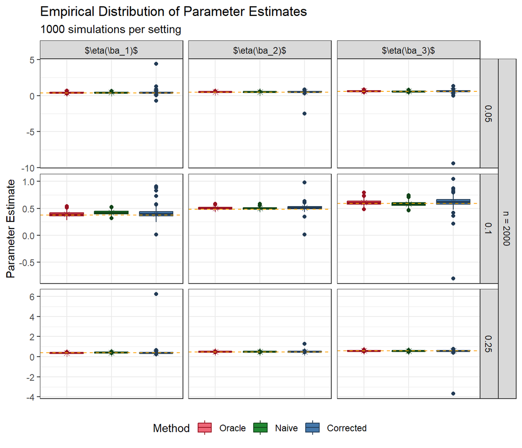

```r
make.plot()
```

### Table of Simulation Results

Below is a table of the empirical bias, empirical standard error, mean estimated standard error, and empirical coverage probability of the crude and bias-corrected 95% CIs corresponding to $\textrm{E}\{Y(\pmb{a})\}$.

```r
tbl <- sim.out.long %>%
  filter(method == "Corrected" &
         !is.na(ghat) &
         stde < 100) %>%
  group_by(pi.cc, param) %>%
  summarise(bias = 100 * mean(ghat - g.true, na.rm = T),
            emp.se = 100 * sd(ghat, na.rm = T),
            est.se = 100 * mean(stde),
            ci.cov = 100 * mean(ci.cov, na.rm = T),
            bcest.se = 100 * mean(bste, na.rm = T),
            bcci.cov = 100 * mean(bcci.cov, na.rm = T)) %>%
  left_join(filter(ftc.dat, method == "Corrected")) %>%
  mutate(Param = param.labs[param],
         pi.cc = 100 * pi.cc,
         ftc = 100 * prop.error) %>%
  dplyr::select(pi.cc, Param, bias, emp.se,
                est.se, ci.cov, bcest.se, bcci.cov)
kbl <- tbl %>%
  kable(format = "latex",
        digits = c(0, 0,
                   1, 1,
                   1, 1,
                   1, 1),
        align = c(rep("c", 3),
                  rep("r", 6)),
        booktabs = TRUE,
        linesep = c("", "", "\\addlinespace"),
        escape = FALSE,
        col.names = c("Sub-cohort size", "Parameter",
                      "Bias", "ESE",
                      "ASE", "Cov",
                      "ASE", "Cov")) %>%
  add_header_above(c(" " = 4,
                     "Crude" = 2,
                     "BC" = 2)) %>%
  kable_styling("striped") %>%
  row_spec(row = 0, bold = TRUE)

tbl
```

```
## # A tibble: 9 × 8
## # Groups:   pi.cc [3]
##   pi.cc Param              bias emp.se est.se ci.cov bcest.se bcci.cov
##   <dbl> <chr>             <dbl>  <dbl>  <dbl>  <dbl>    <dbl>    <dbl>
## 1     5 "$\\eta(\\ba_1)$"  4.06  10.1   17.2    90.3    21.3      91.3
## 2     5 "$\\eta(\\ba_2)$"  4.91   4.46   7.19   82.1     7.79     83.3
## 3     5 "$\\eta(\\ba_3)$"  5.76   9.35  14.3    82.4    17.8      83.7
## 4    10 "$\\eta(\\ba_1)$"  2.47   6.81  12.9    92.1    14.1      92.9
## 5    10 "$\\eta(\\ba_2)$"  2.86   3.92   9.23   87.3     9.99     87.9
## 6    10 "$\\eta(\\ba_3)$"  3.40   6.59   8.52   87.8     9.13     88.4
## 7    25 "$\\eta(\\ba_1)$"  1.13   4.32   4.52   92.9     4.92     93.6
## 8    25 "$\\eta(\\ba_2)$"  1.24   2.37   2.42   92.2     2.44     92.1
## 9    25 "$\\eta(\\ba_3)$"  1.35   4.66   4.71   89.5     5.09     90.3
```